# Eliciting prior and posterior predictive distributions through MC approximation

CSSS/STAT 564: Bayesian Statistics for the Social Sciences

William Brown and Alex Jiang

CS&SS 564 (Spring 2021)

# Goals

- Illustrate plug-in approximation of DAG-based joint probability distributions and the marginal distributions they imply
- A practical guide for eliciting prior predictive distributions and posterior predictive distributions
- Predicting identically generated data sets

# Prediction in general

- Our intention in fitting probability models to data is often to understand the DGP underlying the data, often for the sake of making informed decisions about future outcomes.
- Suppose that the underlying data generating process is as follows: $Y$ is generated according to a distribution characterized by (possibly unknown) parameter $\theta_m$ -- $Y\sim\mathrm{Dist}_m\left(\theta_m\right)$. Our goal is to describe the distribution of new values $\tilde{Y}$ coming from such distribution, before there are observed.
  - such procedure of making inferences about an unknown observable is often called **predictive inference**.
  - Let $\widetilde{Y}$ denote a "predictand"---a class of unknown quantities for which we intend to estimate future values. this quantity has the same domain as realized values of $Y$: $\widetilde{Y}=y\in\mathcal{Y}$. For greater succinctness, we can abbreviate the expression $\widetilde{Y}=y$ more simply as $\tilde{y}$.

**Question:** how do we do predictive inference, given the model we just described?

- If $Y\sim\mathrm{Dist}_m\left(\theta_m\right)$ and we knew $\theta_m$ exactly, then $\mathrm{Dist}_m\left(\theta_m\right)$ would double as a **predictive distribution**, i.e. $\widetilde{Y}\sim\mathrm{Dist}_m\left(\theta_m\right)$
  - However, we never know the true value $\theta_m$ (at least practically speaking). All we know (based on the model we specified) is the prior distribution of $\theta$.

**Bayesian prediction framework allows us to incorporate our (modeled) uncertainty regarding this fixed but unknown quantity.**

- When we don't know $\theta_m$, our prediction of $\widetilde{Y}$ requires us to elicit predictive probabilities $p(\tilde{y})$ by applying the Rule of Total Probability to the joint distribution $p(\tilde{y},\theta_m)$:
  $$p(\tilde{y})=\int_{\Theta_m} p(\tilde{y},\theta_m) \; d\theta_m$$
- The joint probability function $p(\tilde{y},\theta_m)$ can be decomposed into (A) a model for the DGP underlying $\widetilde{Y}$ conditional on $\theta_m$, and (B) a model for our uncertainty/belief regarding $\theta_m$:
  $$p(\tilde{y},\theta_m)=p(\tilde{y}|\theta_m) \times p(\theta_m)$$
  $$\therefore p(\tilde{y})=\int_{\Theta_m} p(\tilde{y}|\theta_m) \; p(\theta_m) \; d\theta_m$$
  - An interpretation: Ideally we would want to sample $\tilde{y}$ from $p(\tilde{y}|\theta_{true})$, where $\theta_{true}$ is the true value of the unknown parameter. Since we don't know the true value of $\theta_m$, we incorporate our prior belief about this parameter to 'faciliate our guess', by taking a 'weighted average' wrt the prior distribution of $\theta_m$.

Depending on whether we have observed data $Y=y$ coming from the same process, the predictive distribution we use to describe the unknown data $\tilde{y}$ can be categorized into **prior predictive distribution** and **posterior predictive distribution**.

- the marginal distribution $p(\tilde{y})$ above is also called the **prior predictive distribution**, because:
  - (**prior**): it is not based on observed data:
  - (**predictive**): it is the distribution of $\tilde{y}$, which is observable (we're about to observe it) but unknown (we haven't observed it yet)

We will learn how to sample values from the prior predictive distribution through plug-in approximation in the following section:

- This implies a very simple DAG decomposition of the full probability model:

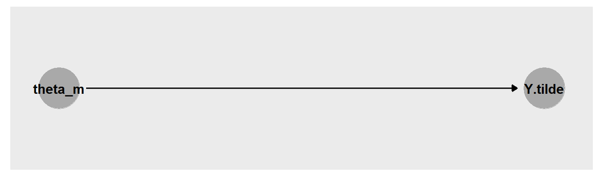

```r
# Illustration of a DAG for a univariate DGP when the model parameters are unknown
theme_set(theme_dag_gray())

simpleDAG.coords = list(
  x = c(
    theta_m = 1, Y.tilde = 2
    ),
  y = c(
    theta_m = 1, Y.tilde = 1
    )
  )

simpleDAG = dagify(

  Y.tilde ~ theta_m, # Child on the left of the tilde, parent(s) on the right of the tilde separated by '+'

  coords = simpleDAG.coords
  )

simpleDAG %>%
  ggdag() +
  geom_dag_node(color = "dark gray", internal_color = "dark gray") +
  geom_dag_text(col = "black")
```

# Plug-in approximation of prior predictive distributions---the case of the gamma-Poisson model

- While there are a small handful of analytical solutions for marginal predictive distributions $p(\tilde{y})$, these are mostly for "toy" problems. In most realistic data-analytic circumstances, plug-in approximation is favored as an efficient alternative.
- Basic procedure: draw a large MC sample from the joint PD of $\widetilde{Y}$ and $\theta_m$, then summarize only the marginal sample distribution of $\widetilde{Y}$.
- Recall: sampling from a joint PD model based on a DAG is straightforward:
  - Simulate $S$ observations from the DAG's root nodes (quantities represented by nodes with no parents): $\{\theta_m^{(1)},\dots,\theta_m^{(S)}\}\stackrel{iid}{\sim}\mathrm{Dist}_{\theta_m}$
  - Pass this output as input for the simulation of child quantities: $y^{(s)}\sim \mathrm{Dist}_m\left(\theta_m^{(s)}\right)$
  - Repeat this process until the terminal nodes are reached (quantities represented by nodes with no children).
- Where does $p(\theta_m)$ come from?
  - In general, it is some degree-of-belief budget about this uncertain quantity, $p(\theta_m|\eta)$, where $\eta$ are the hyper-parameters of this model.
  - It could be a prior PD model, $p(\theta_m|\eta_0)$, where $\eta_0$ are the prior hyper-parameters.
  - It could be a posterior PD model, $p(\theta_m|\eta_0,y)$, where $\eta_0$ are again the prior hyper-parameters and $y$ abbreviates observed data used to further condition or update our belief about $\theta_m$.

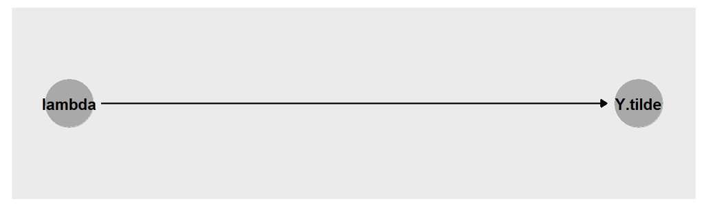

```r
# Illustration of a DAG for a univariate Poisson DGP when lambda is unknown
PriorPredDistDAG.coords = list(
  x = c(
    lambda = 1, Y.tilde = 2
    ),
  y = c(
    lambda = 1, Y.tilde = 1
    )
  )

PriorPredDistDAG = dagify(

  Y.tilde ~ lambda,

  coords = PriorPredDistDAG.coords
  )

PriorPredDistDAG %>%
  ggdag() +
  geom_dag_node(color = "dark gray", internal_color = "dark gray") +
  geom_dag_text(col = "black")
```

$$\tilde{y}\in\{0,1,2,\dots\} \quad \quad \lambda\in\mathbb{R}_{>0}$$

$$p(\tilde{y},\lambda|a_0,b_0)=P(\tilde{y}|\lambda)\times p(\lambda|a_0,b_0)$$

$$\widetilde{Y}\sim \mathrm{Poisson}(\lambda)$$

$$\lambda \sim \mathrm{Gamma}(a_0,b_0)$$

$a_0$ is a prior shape hyper-parameter and $b_0$ is a prior concentration hyper-parameter.

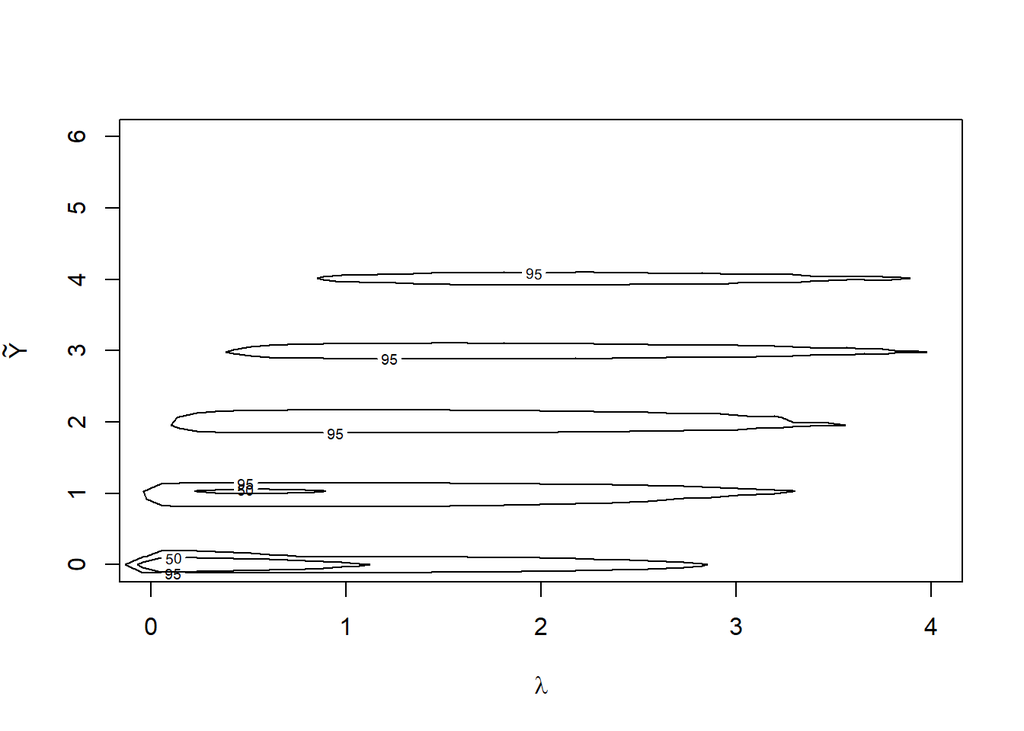

```r
# MC simulation of the joint distribution of lambda and the Poisson-distributed estimand based on a prior model of lambda
a_0 = b_0 = 1; S=100000; set.seed(564)
lambdaSim = rgamma(n = S, shape = a_0, rate = b_0)
Y.tildeSim = rpois(n = S, lambda = lambdaSim)

# Illustration of the approximated joint prior distribution of lambda and the Poisson-distributed estimand
jointPlugInApprox = ks::kde(x = cbind(lambdaSim, Y.tildeSim))
plot(
  x=jointPlugInApprox, # For help plotting kde objects, see ?plot.kde
  cont = c(50, 95), # Percentiles to draw highest-probability regions
  xlim = c(0,4), ylim = c(0, 6),
  xlab = expression(lambda), ylab = expression(tilde(Y))
  )
```

(Note that this contour plot treats $\widehat{Y}$ as if it were continuous rather than discrete.)

- The marginal prior predictive distribution of $\widetilde{Y}$ can then be approximated by plotting out only the simulated vector $\{\widetilde{Y}^{(1)},\dots,\widetilde{Y}^{(S)}\}$:

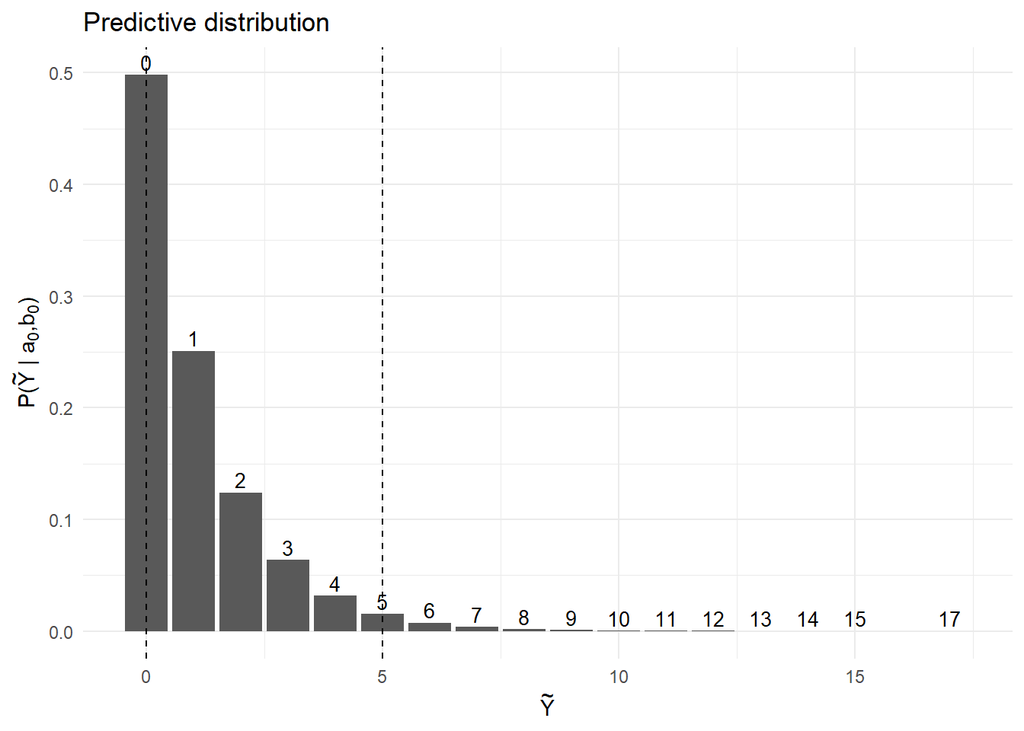

Plug-in prior predictive distribution approximation for the gamma-Poisson model. The dashed vertical line shows the 95% quantile-based credible interval.

```r
# Illustration of the approximated marginal prior distribution of the Poisson-distributed estimand
df <- tibble(x = as.integer(rownames(table(Y.tildeSim))),
             y = table(Y.tildeSim)/S)
ggplot(df, aes(x=x, y=y)) + geom_bar(stat="identity") +
  geom_text(aes(label=x), vjust=-0.3, size=3.5)+theme_minimal() +
  xlab(expression(tilde(Y))) + ylab(expression(paste("P(",tilde(Y)," | a"[0],",b"[0],")")))+
  geom_vline(xintercept = quantile(x = Y.tildeSim, probs = c(0.025,.975)), lty = 2) +
  ggtitle("Predictive distribution")
```

# Plug-in approximation of posterior predictive distributions---the case of the gamma-Poisson model

If we already observed data from the data-generating process $y$, the distribution of new unknown observable $\tilde{y}$, given the previous data $\tilde{y}$ (note their notational difference!) is called **posterior predictive distribution**, denoted as $p(\tilde{y}|y)$.

- How we derive $p(\tilde{y}|y)$ is very similar to what we did before: we first apply the Rule of Total Probability

$$p(\tilde{y} \mid y)=\int_{\Theta_m} p(\tilde{y}, \theta_m \mid y) d \theta_m$$

- We can similarly decompose the joint posterior probability function $p(\tilde{y}, \theta_m|y)$ into (A) a model for the DGP underlying $\tilde{Y}$ conditional on $\theta_m$, **given** our prior knowledge of $y$, and (B) the posterior distribution for our unknown parameter $\theta_m$ given $y$:

$$\begin{array}{r}
p\left(\tilde{y}, \theta_{m}|y\right)=p\left(\tilde{y} \mid \theta_{m},y\right) \times p\left(\theta_{m}|y\right) \\
\therefore p(\tilde{y}|y)=\int_{\Theta_{m}} p\left(\tilde{y} \mid \theta_{m},y\right) p\left(\theta_{m}|y\right) d \theta_{m}
\end{array}$$

- Finally, based on our DAG model, we have **assumed conditional independence** of $y$ and $\tilde{y}$ given $\theta$:

$$p(\tilde{y} \mid y)=\int_{\Theta_{m}} p\left(\tilde{y} \mid \theta_{m}, y\right) p\left(\theta_{m} \mid y\right) d \theta_{m} = \int_{\Theta_{m}} p\left(\tilde{y} \mid \theta_{m}\right) p\left(\theta_{m} \mid y\right) d \theta_{m}$$

- Derivation of this result requires theory on d-separation for DAGs and is beyond the scope of today's lecture, but here's one possible interpretation for this: $\theta_m$ is the common and only cause for $\tilde{y}$ and $y$, so we wouldn't gain extra information about $\tilde{y}$ if we already controlled/conditioned on $\theta_m$, even if we observed $y$ in the first place.
- This is called 'Principle of the Common Cause' and you can find more information here if you're interested: https://www.andrew.cmu.edu/user/scheines/tutor/d-sep.html
- To illustrate, let us first generate a sample of 5 observations from a known Poisson distribution:
  $$\{Y_1,\dots,Y_5\}\stackrel{iid}{\sim}\mathrm{Poisson}(\lambda=5)$$

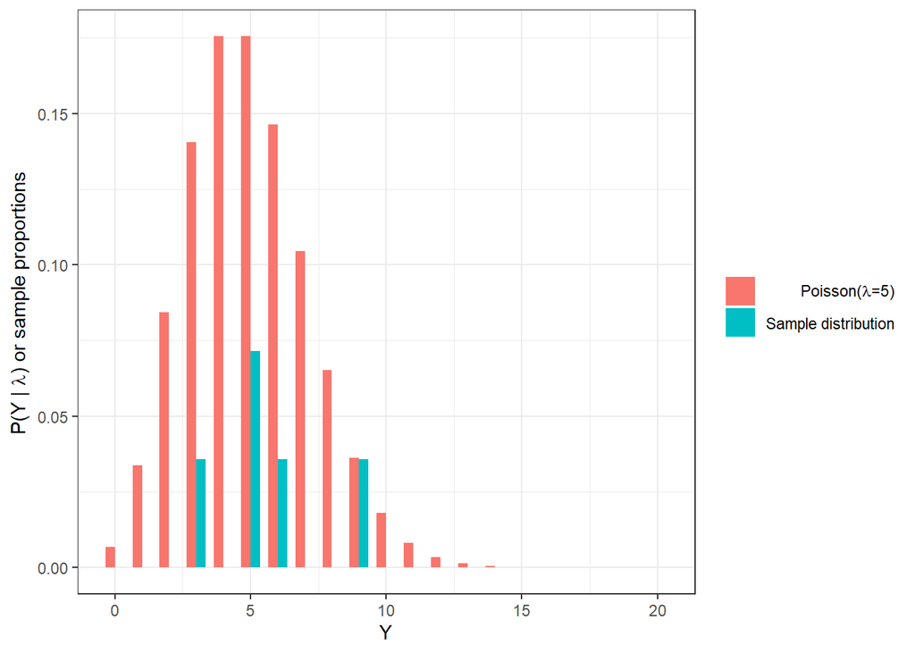

```r
# Illustration of a known {Y_1,...,Y_5} ~ Poisson(lambda=5) sample
check_occurences <- function(x) {
  return(sum(Y.Sim %in% x))
}
Y.Sim = rpois(n = 5, lambda = 5)
df <- tibble(x = 0:20, y1 = dpois(x = 0:20, lambda = 5),
             y2 = sapply(0:20, check_occurences)/sum(Y.Sim)) %>%
  pivot_longer(!x,names_to = "type", values_to = "probs")
ggplot(df) + geom_bar(stat='identity',
                      aes(x = x, y = probs, fill = factor(type)),
                      position=position_dodge(width = .7), width = .7)+
  theme_bw() + xlab("Y") + ylab(expression(paste("P(Y | ", lambda,") or sample proportions"))) +
  theme(legend.title = element_blank()) +
  scale_fill_discrete(labels = c(expression(paste("Poisson(",lambda,"=5)"), "Sample distribution")))
```

- Eliciting posterior predictive distributions involves simulating from a joint distribution that includes not only the predictand and model parameter(s) but also observed data:

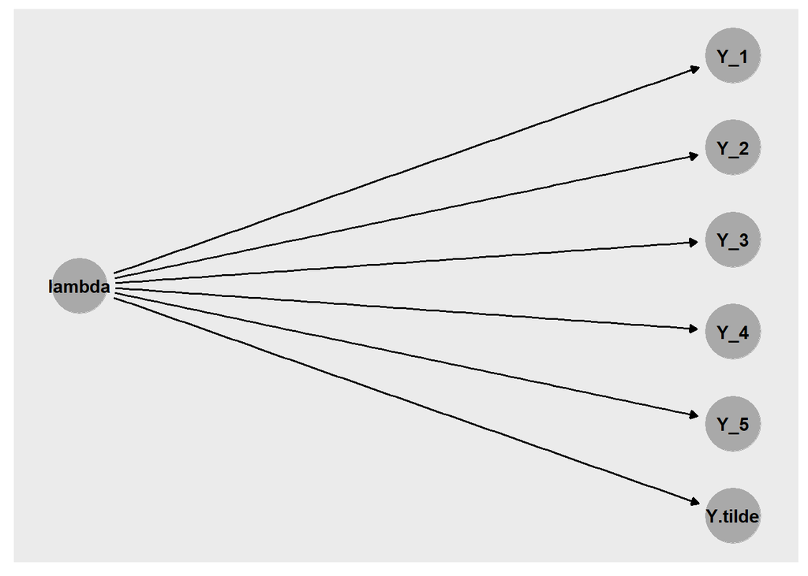

```r
# Illustration of a DAG for a univariate Poisson DGP when lambda is unknown, with both observed and unobserved/predicted values of Y
PostPredDistDAG.coords = list(
  x = c(
    lambda = 1, Y_1 = 2, Y_2 = 2, Y_3 = 2, Y_4 = 2, Y_5 = 2, Y.tilde = 2
    ),
  y = c(
    lambda = 1, Y_1 = 3.5, Y_2 = 2.5, Y_3 = 1.5, Y_4 = 0.5, Y_5 = -0.5, Y.tilde = -1.5
    )
  )

PostPredDistDAG = dagify(

  Y_1 ~ lambda,
  Y_2 ~ lambda,
  Y_3 ~ lambda,
  Y_4 ~ lambda,
  Y_5 ~ lambda,
  Y.tilde ~ lambda,

  coords = PostPredDistDAG.coords
  )

PostPredDistDAG %>%
  ggdag() +
  geom_dag_node(color = "dark gray", internal_color = "dark gray") +
  geom_dag_text(col = "black")
```

- However, in this case, we know several values represented in the joint distribution so we must apply a different strategy for sampling from the DAG. The easiest and fully sufficient way is to simulate from the posterior distribution of $\lambda$, then to simulate the predictand as before.
- For the gamma-Poisson model, an analytical solution is available for the posterior distribution with the following posterior shape and concentration hyper-parameters:
  $$\lambda|y\sim\mathrm{Gamma}\left(a_n=a_0+\sum_{i=1}^n y_i,b_n=b_0+n\right)$$

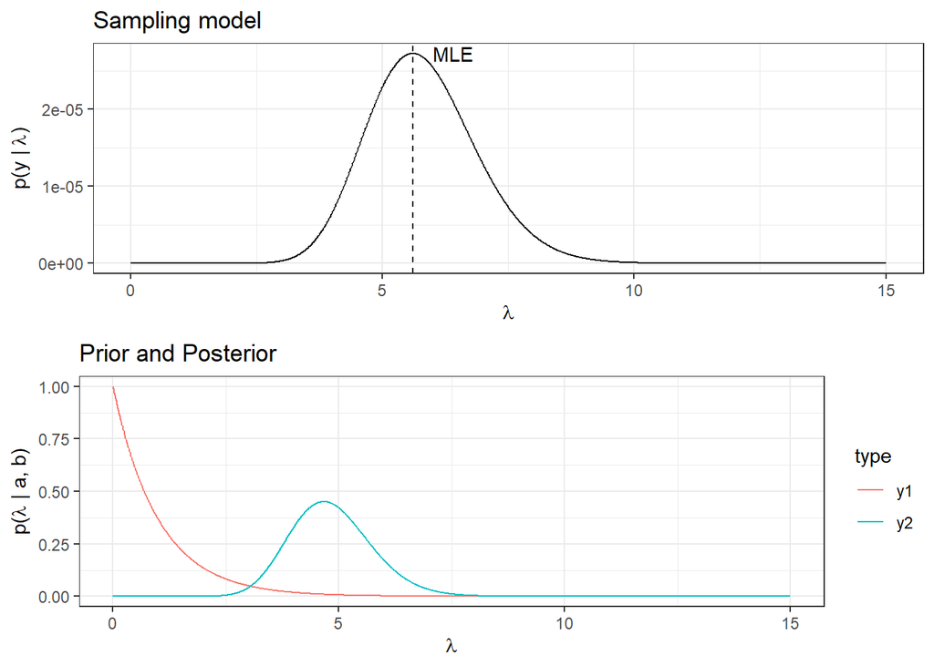

```r
# MC simulation of the joint distribution of lambda and the Poisson-distributed estimand based on a posterior model of lambda
a_n = a_0+sum(Y.Sim); b_n = b_0+5
lambdaPostSim = rgamma(n = S, shape = a_n, rate = b_n)
Y.tildePostSim = rpois(n = S, lambda = lambdaPostSim)

# Illustration of the likelihood, prior, and posterior over Lambda
likelihoods = exp(colSums(apply(
    X = matrix(seq(0, 15, 0.01), ncol = 1),
    MARGIN = 1,
    FUN = dpois, x = Y.Sim, log = TRUE
    )))

df1 <- tibble(x = seq(0, 15, 0.01), y = likelihoods)
p1 <- ggplot(df1, aes(x = x, y = y)) + geom_line() + xlab(expression(lambda)) +
  ylab(expression(paste("p(y | ",lambda,")"))) +
  geom_vline(xintercept = mean(Y.Sim), lty = 2) + theme_bw() +
  ggtitle("Sampling model")
p1 <- p1 + annotate("text", x = mean(Y.Sim)+0.8, y=max(likelihoods), label = "MLE")
df2 <- tibble(x = seq(0, 15, 0.01), y1 = dgamma(x=seq(0, 15, 0.01),
                                               shape = a_0, rate = b_0),
              y2 = dgamma(x=seq(0, 15, 0.01), shape = a_n, rate = b_n)) %>%
  pivot_longer(!x, names_to = "type", values_to = "prob")
p2 <- ggplot(df2, aes(x = x, y = prob, col = type, group = type)) + geom_line() +
  theme(legend.title = element_blank()) +
  ggtitle("Prior and Posterior") + theme_bw() +
  scale_fill_discrete(labels = c(
    expression(paste("Prior for ",lambda)),
    expression(paste("Posterior for ",lambda))
    )) + xlab(expression(lambda)) + ylab(expression(paste("p(",lambda," | a, b)")))
p <- grid.arrange(p1, p2, ncol = 1)
```

```r
p
```

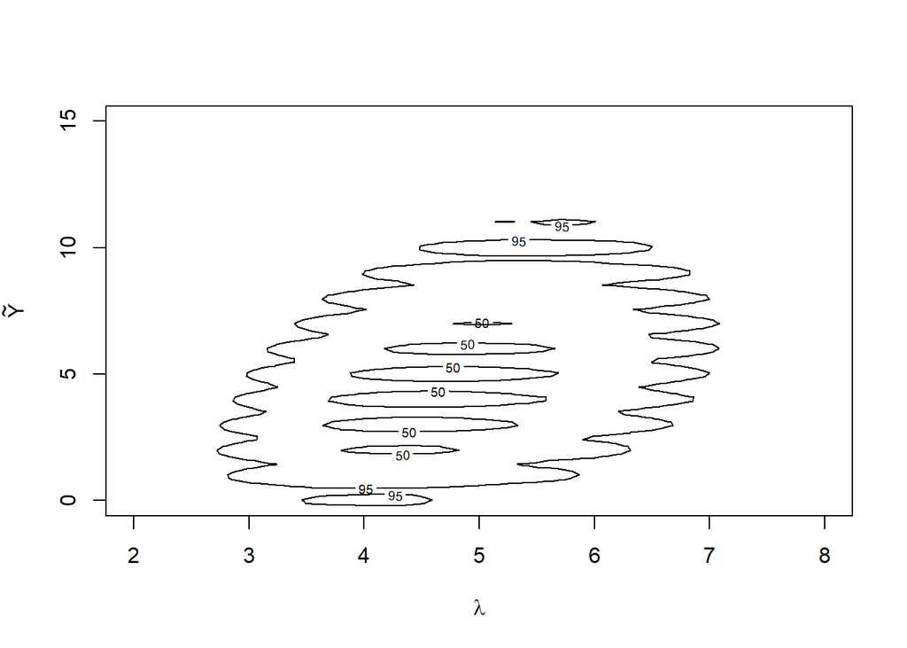

```r
# Illustration of the approximated joint posterior distribution of lambda and the Poisson-distributed predictand
jointPostPlugInApprox = ks::kde(x = cbind(lambdaPostSim, Y.tildePostSim))
par(mfrow = c(1, 1))
plot(
  x=jointPostPlugInApprox, # For help plotting kde objects, see ?plot.kde
  cont = c(50, 95), # Percentiles to draw highest-probability regions
  xlim = c(2,8), ylim = c(0, 15),
  xlab = expression(lambda), ylab = expression(tilde(Y))
  )
```

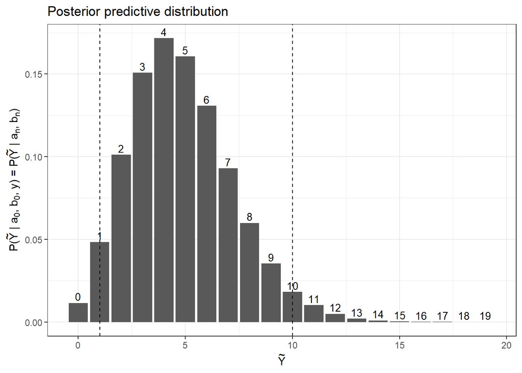

```r
# Illustration of the approximated marginal posterior distribution of the Poisson-distributed estimand
# 95% highest-probability predictive predictive interval
df <- tibble(x = as.integer(rownames(table(Y.tildePostSim))),
             y = table(Y.tildePostSim)/S)
ggplot(df, aes(x=x, y=y)) + geom_bar(stat="identity") +
  geom_text(aes(label=x), vjust=-0.3, size=3.5)+theme_minimal() +
  xlab(expression(tilde(Y))) + ylab(expression(paste("P(",tilde(Y)," | a"[0],", b"[0],", y) = P(",tilde(Y)," | a"[n],", b"[n],")")))+
  geom_vline(xintercept = quantile(x = Y.tildePostSim, probs = c(0.025,.975)), lty = 2) +
  ggtitle("Posterior predictive distribution")+ theme_bw()
```

# Comparing prior and posterior predictive distributions

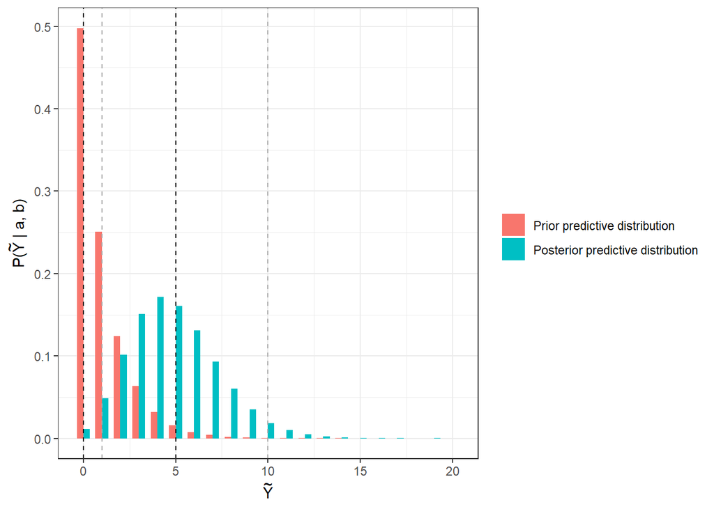

```r
# Illustration comparing the approximated marginal prior and posterior distributions of the Poisson-distributed predictand
check_occurences_1 <- function(x) {
  return(sum(Y.tildeSim %in% x))
}
check_occurences_2 <- function(x) {
  return(sum(Y.tildePostSim %in% x))
}
df <- tibble(x = 0:20, y1 = sapply(0:20, check_occurences_1)/S,
             y2 = sapply(0:20, check_occurences_2)/S) %>%
  pivot_longer(!x, names_to = "type", values_to = "probs")
ggplot(df) + geom_bar(stat='identity',
                      aes(x = x, y = probs, fill = factor(type)),
                      position=position_dodge(width = .7), width = .7)+
  theme_bw() + xlab(expression(tilde(Y))) +
  ylab(expression(paste("P(",tilde(Y)," | a, b)"))) +
  geom_vline(xintercept = quantile(x = Y.tildeSim, probs = c(0.025,0.975)),
             lty = 2, col = "black") +
  geom_vline(xintercept = quantile(x = Y.tildePostSim, probs = c(0.025,0.975)),
             lty = 2, col = "dark gray") +
  theme(legend.title = element_blank()) +
  scale_fill_discrete(labels = c("Prior predictive distribution",
                                 "Posterior predictive distribution"))
```

# Simulating posterior (or prior) predictive distributions for whole samples

- Rather than drawing a single observation from the DGP model for each simulated value of $\theta_m$, we can draw whole samples if we wish:
  $$\begin{array}{cc}
  \{\widetilde{Y}_1^{(1)},\dots,\widetilde{Y}_n^{(1)}\}\stackrel{iid}{\sim}\mathrm{Dist}_m(\theta_m^{(1)}) \\
  \{\widetilde{Y}_1^{(2)},\dots,\widetilde{Y}_n^{(2)}\}\stackrel{iid}{\sim}\mathrm{Dist}_m(\theta_m^{(2)}) \\
  \vdots \\
  \{\widetilde{Y}_1^{(S)},\dots,\widetilde{Y}_n^{(S)}\}\stackrel{iid}{\sim}\mathrm{Dist}_m(\theta_m^{(S)})
  \end{array}$$
- If (A) a particular summary statistic is calculated for each sample and (B) each sample is identical in size to the original sample, this simulation yields an approximation of a posterior predictive distribution of the chosen summary statistic, providing a Bayesian equivalent to a frequentist sampling distribution.

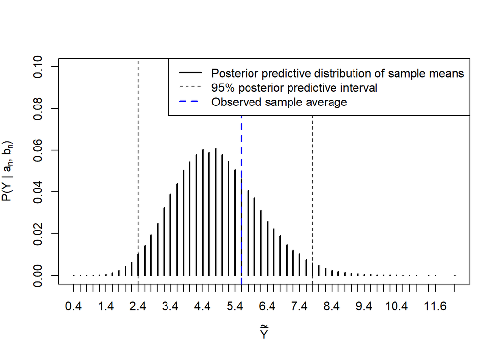

```r
# Simulating a posterior predictive distribution of sample means for a Poisson model
Sample.tildePostSim = apply(
  X = as.matrix(lambdaPostSim, ncol=1), MARGIN = 1, FUN = rpois, n=5
  )
# Plotting the predictive distribution and comparing to the observed sample mean
plot(
  x=table(colMeans(Sample.tildePostSim))/S,
  xlab = expression(tilde(bar(Y))),
  ylab = expression(paste("P(",tilde(bar(Y))," | a"[n],", b"[n],")")),
  ylim = c(0, 0.1)
  )
abline(v = quantile(colMeans(Sample.tildePostSim), probs = c(0.025, 0.975)), lty = 2)
abline(v = mean(Y.Sim), lty = 2, col = "blue", lwd = 2)
legend(
  "topright",
  legend = c(
    "Posterior predictive distribution of sample means",
    "95% posterior predictive interval",
    "Observed sample average"
    ),
  lwd = c(2, 1, 2), lty = c(1, 2, 2), col = c("black", "black", "blue")
  )
```